# Hatchability, Body Weight, and Ceca Weight Analysis.Rmd

Chloe J McGovern

2026-03-31

```r
#Load packages
pacman::p_load(tidyverse, install = FALSE)

#load times new roman font
windowsFonts("Times New Roman" = windowsFont("Times New Roman"))

theme(
    text = element_text(family = "Times New Roman")
)
```

[output not shown]

# Hatchability

On day 21 (embryonic), the Gallus gallus embryos hatch into prococial chicks. For this study, there were 6 groups of 26 eggs. The groups were

1. Non injection
2. Sterile MilliQ water
3. Sterile 0.85% NaCl MilliQ water
4. MIX Dose 1 (lowest)
5. MIX Dose 2
6. MIX Dose 3 (highest)

The raw hatch data was as follows;

1. 23 out of 26 (88.46%)
2. 7 out of 26 (26.92%)
3. 0 out of 26 (0%)
4. 24 out of 26 (92.31%)
5. 26 out of 26 (100%)
6. 24 out of 26 (92.31%)

Based on the raw hatch data, there are clear differences in hatchability rates among the groups. I hypothesize that the low temperature of water stored in the freezer prior to injection shocked the eggs and therefore decreased hatchability. Additionally, the saline still had ice in it, so the hypothesis is that the salt precipitated out of the frozen water, making the salinity higher than 0.85% and enough to kill the embryos.

# Body Weight at Hatch Analysis

## Transform the data set

```r
raw_body_weight <- read_csv("Data/CSVs/weight_mix_study_mar25.csv")
glimpse(raw_body_weight)
```

```
## Rows: 26
## Columns: 7
## $ bird_num <dbl> 1, 2, 3, 4, 5, 6, 7, 8, 9, 10, 11, 12, 13, 14, 15, 16, 17, 18…
## $ no_inj   <dbl> 42.0, 44.1, 39.0, 36.6, 42.2, 34.9, 42.3, 41.2, 37.3, 39.9, 4…
## $ water    <dbl> 36.5, 41.7, 43.7, 38.1, 40.9, 44.0, 43.5, NA, NA, NA, NA, NA,…
## $ saline   <lgl> NA, NA, NA, NA, NA, NA, NA, NA, NA, NA, NA, NA, NA, NA, NA, N…
## $ mix_1    <dbl> 39.5, 36.0, 40.0, 43.0, 42.0, 43.0, 42.0, 37.0, 44.5, 39.5, 3…
## $ mix_2    <dbl> 45.5, 41.5, 42.0, 40.5, 38.0, 39.0, 43.0, 40.0, 39.0, 42.0, 4…
## $ mix_3    <dbl> 42.5, 40.0, 39.5, 43.0, 43.0, 46.0, 39.0, 41.5, 40.5, 39.5, 4…
```

```r
body_weight_long <- raw_body_weight %>%
  select(-saline, -bird_num) %>%    # drop saline AND bird_num
  pivot_longer(
    cols = everything(),      # pivot everything left
    names_to = "treatment",
    values_to = "body_weight")

glimpse(body_weight_long)
```

```
## Rows: 130
## Columns: 2
## $ treatment   <chr> "no_inj", "water", "mix_1", "mix_2", "mix_3", "no_inj", "w…
## $ body_weight <dbl> 42.0, 36.5, 39.5, 45.5, 42.5, 44.1, 41.7, 36.0, 41.5, 40.0…
```

Yay! our data frame looks good! We transformed the wide data set into a long form column and dropped our saline control group that did not hatch.

## Time to run an ANOVA and Tukey Pairwise for Body Weight

```r
# run ANOVA
anova_body <- aov(body_weight ~ treatment, data = body_weight_long)
summary(anova_body)
```

```
##             Df Sum Sq Mean Sq F value Pr(>F)
## treatment    4   28.9   7.216   1.032  0.395
## Residuals   99  692.1   6.991
## 26 observations deleted due to missingness
```

```r
# run TUKEY
tukey_body <- TukeyHSD(anova_body)
tukey_body
```

```
##   Tukey multiple comparisons of means
##     95% family-wise confidence level
##
## Fit: aov(formula = body_weight ~ treatment, data = body_weight_long)
##
## $treatment
##                    diff        lwr      upr     p adj
## mix_2-mix_1   1.4070513 -0.6726083 3.486711 0.3348652
## mix_3-mix_1   1.0625000 -1.0583450 3.183345 0.6341708
## no_inj-mix_1  0.5090580 -1.6347158 2.652832 0.9643946
## water-mix_1   0.4916667 -2.6642517 3.647585 0.9925831
## mix_3-mix_2  -0.3445513 -2.4242109 1.735108 0.9906243
## no_inj-mix_2 -0.8979933 -3.0010307 1.205044 0.7590757
## water-mix_2  -0.9153846 -4.0437742 2.213005 0.9260487
## no_inj-mix_3 -0.5534420 -2.6972158 1.590332 0.9520584
## water-mix_3  -0.5708333 -3.7267517 2.585085 0.9869357
## water-no_inj -0.0173913 -3.1887637 3.153981 1.0000000
```

The `anova_body` p value is 0.395, therefore no significant difference in body weight at hatch. However, I still wanted to run a Tukey pair-wise comparison to see if there was something further able to detect statistically. The `tukey_body` results confirmed that there are no significant differences between groups.

## Let’s plot the body weight data

```r
# get ANOVA p-value
anova_p_body <- summary(anova_body)[[1]]$`Pr(>F)`[1]  # pulls the p-value
anova_p_body_text <- paste0("ANOVA p = ", signif(anova_p_body, 3)) # confirm correct p-value

# make treatment factor with custom labels and order
body_weight_long <- body_weight_long %>%
  mutate(treatment = factor(treatment,
    levels = c("no_inj", "water", "mix_1", "mix_2", "mix_3"),
    labels = c("No Injection", "Water", "Mix Dose 1", "Mix Dose 2", "Mix Dose 3")
  ))

y_max <- max(body_weight_long$body_weight, na.rm = TRUE)

# load colors
source("C:/Users/Chloe/OneDrive - Cornell University/study-1-march25/MIX/Code/colors.R")
str(treatment_colors)
```

```
##  Named chr [1:5] "#666666" "goldenrod1" "coral2" "cyan3" "mediumseagreen"
##  - attr(*, "names")= chr [1:5] "No Injection" "Water" "Mix Dose 1" "Mix Dose 2" ...
```

```r
unique(body_weight_long$treatment)
```

```
## [1] No Injection Water        Mix Dose 1   Mix Dose 2   Mix Dose 3
## Levels: No Injection Water Mix Dose 1 Mix Dose 2 Mix Dose 3
```

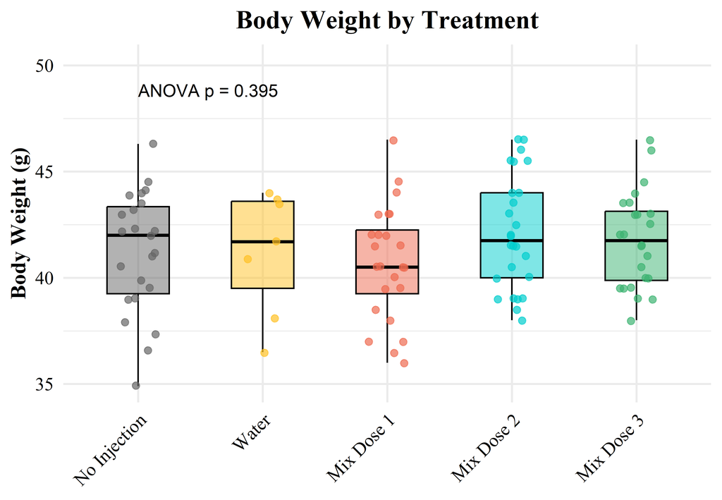

```r
# plot it
ggplot(body_weight_long, aes(treatment, body_weight)) +
  geom_boxplot(aes(fill = treatment),
               outlier.shape = NA, width = 0.5, color = "black", alpha = 0.5) +
  geom_jitter(aes(color = treatment),
              width = 0.15, alpha = 0.7, size = 2) +
  scale_fill_manual(values  = treatment_colors) +
  scale_color_manual(values = treatment_colors) +
  theme_minimal(base_size = 14) +
  expand_limits(y = y_max * 1.08) +
  annotate("text", x = 1, y = y_max * 1.05,
           label = anova_p_body_text, hjust = 0, size = 4) +
  labs(
    title = "Body Weight by Treatment",
    y     = "Body Weight (g)",
    x     = NULL
  ) +
  theme(
    text            = element_text(family = "Times New Roman"),
    plot.title      = element_text(face = "bold", hjust = 0.5),
    axis.title      = element_text(face = "bold"),
    axis.text       = element_text(size = 12, color = "black"),
    axis.text.x     = element_text(angle = 45, hjust = 1),
    legend.position = "none"
  )
```

# Ceca weight analysis

## Transform the data set

```r
raw_ceca_weight <- read_csv("Data/CSVs/ceca_weight_mix_study_mar25.csv")
glimpse(raw_ceca_weight)
```

```
## Rows: 16
## Columns: 7
## $ bird_num <dbl> 1, 2, 3, 4, 5, 6, 7, 8, 9, 10, 11, 12, 13, 14, 15, 16
## $ no_inj   <dbl> 2.2, 2.2, 2.4, 2.1, 2.3, 2.1, 2.1, 2.3, 2.0, 2.1, 2.1, 2.0, 2…
## $ water    <dbl> 2.1, 2.3, 2.1, 2.1, 2.0, 2.1, 2.1, NA, NA, NA, NA, NA, NA, NA…
## $ saline   <lgl> NA, NA, NA, NA, NA, NA, NA, NA, NA, NA, NA, NA, NA, NA, NA, NA
## $ mix_1    <dbl> 2.1, 2.3, 2.1, 2.1, 2.3, 2.2, 2.1, 2.2, 2.2, 2.1, 2.1, 2.0, 2…
## $ mix_2    <dbl> 2.1, 2.2, 2.2, 2.1, 2.2, 2.1, 2.1, 2.2, 2.1, 2.2, 2.1, 2.0, 2…
## $ mix_3    <dbl> 2.2, 2.1, 2.2, 2.1, 2.1, 2.3, 2.2, 2.2, 2.4, 2.1, 2.2, 2.2, 2…
```

```r
ceca_weight_long <- raw_ceca_weight %>%
  select(-saline, -bird_num) %>%
  pivot_longer(
    cols = c(no_inj, water, mix_1, mix_2, mix_3),   # specify the real ones!
    names_to = "treatment",
    values_to = "ceca_weight"
  ) %>%
  mutate(ceca_weight = ceca_weight - 1.8)


glimpse(ceca_weight_long)
```

```
## Rows: 80
## Columns: 2
## $ treatment   <chr> "no_inj", "water", "mix_1", "mix_2", "mix_3", "no_inj", "w…
## $ ceca_weight <dbl> 0.4, 0.3, 0.3, 0.3, 0.4, 0.4, 0.5, 0.5, 0.4, 0.3, 0.6, 0.3…
```

Looks good–let’s continue with our analysis.

## Time to run ANOVA and Tukey Pairwise on Ceca Weight

```r
# run ANOVA
anova_ceca <- aov(ceca_weight ~ treatment, data = ceca_weight_long)
summary(anova_ceca)
```

```
##             Df Sum Sq Mean Sq F value Pr(>F)
## treatment    4 0.0914 0.02285   1.918  0.118
## Residuals   66 0.7861 0.01191
## 9 observations deleted due to missingness
```

```r
# run TUKEY
tukey_ceca <- TukeyHSD(anova_ceca)
tukey_ceca
```

```
##   Tukey multiple comparisons of means
##     95% family-wise confidence level
##
## Fit: aov(formula = ceca_weight ~ treatment, data = ceca_weight_long)
##
## $treatment
##                       diff         lwr        upr     p adj
## mix_2-mix_1  -2.500000e-02 -0.13321515 0.08321515 0.9664433
## mix_3-mix_1   6.250000e-02 -0.04571515 0.17071515 0.4903317
## no_inj-mix_1 -2.500000e-02 -0.13321515 0.08321515 0.9664433
## water-mix_1  -3.571429e-02 -0.17441796 0.10298938 0.9506508
## mix_3-mix_2   8.750000e-02 -0.02071515 0.19571515 0.1685186
## no_inj-mix_2  1.110223e-16 -0.10821515 0.10821515 1.0000000
## water-mix_2  -1.071429e-02 -0.14941796 0.12798938 0.9994976
## no_inj-mix_3 -8.750000e-02 -0.19571515 0.02071515 0.1685186
## water-mix_3  -9.821429e-02 -0.23691796 0.04048938 0.2841961
## water-no_inj -1.071429e-02 -0.14941796 0.12798938 0.9994976
```

The p-value for the `anova_ceca` is 0.118. This means there are no significant differences in the ceca weight at hatch. This was expected because 1) a disease model was not introduced to cause a significant effect on the ceca weight and 2) the sensitivity of the scale at the farm is limited so that may inhib any difference at the milligram level to be detected.

Likewise for the `tukey_ceca` analyis, there was no significant difference as the pairwise level for the treatments and the groups.

## Let’s plot this!

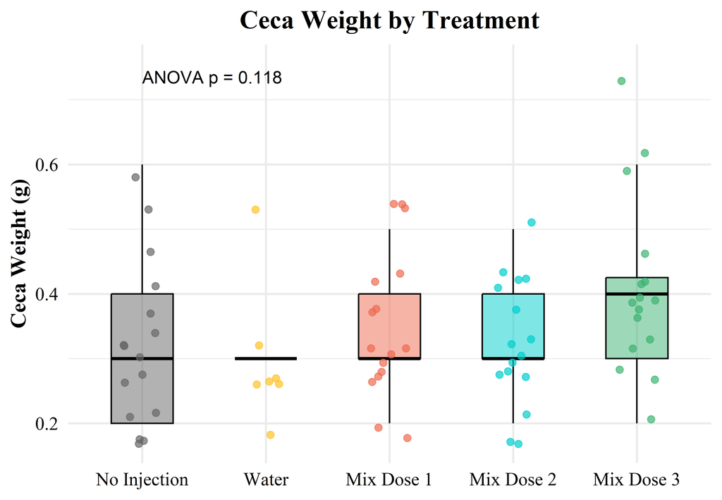

```r
# get ANOVA p-value
anova_p_ceca <- summary(anova_ceca)[[1]]$`Pr(>F)`[1]  # pulls the p-value
anova_p_ceca_text <- paste0("ANOVA p = ", signif(anova_p_ceca, 3)) # confirm correct p-value

# make treatment factor with custom labels and order
ceca_weight_long <- ceca_weight_long %>%
  mutate(treatment = factor(treatment,
    levels = c("no_inj", "water", "mix_1", "mix_2", "mix_3"),
    labels = c("No Injection", "Water", "Mix Dose 1", "Mix Dose 2", "Mix Dose 3")
  ))

y_max_ceca <- max(ceca_weight_long$ceca_weight, na.rm = TRUE)

ggplot(ceca_weight_long, aes(x = treatment, y = ceca_weight)) +
    geom_boxplot(aes(fill = treatment), outlier.shape = NA, color = "black", alpha = 0.5, width = 0.5) +  # Lighter box plots
    geom_jitter(aes(color = treatment), width = 0.15, alpha = 0.7, size = 2) +
    scale_color_manual(values = treatment_colors) +  # Custom color palette (matching previous plot)
    scale_fill_manual(values = treatment_colors) +  # Custom color palette (for fill)
    theme_minimal(base_size = 14) +
    expand_limits(y = y_max_ceca * 1.08) +  # Adjust the y-axis limits
    annotate("text", x = 1, y = y_max_ceca * 1.05, label = anova_p_ceca_text, hjust = 0, size = 4) +  # Annotation
    labs(
        x = NULL,
        y = "Ceca Weight (g)",
        title = "Ceca Weight by Treatment"
    ) +
    theme(
        text = element_text(family = "Times New Roman"),
        plot.title = element_text(face = "bold", hjust = 0.5),
        axis.title = element_text(face = "bold"),
        axis.text = element_text(size = 12, color = "black"),
        legend.position = "none"
    )
```

# In Conclusion

The probiotic mixtures did not effect the hatchability or development of the chick.